# Tema 10 - Fundamentos Estadísticos

Universidad de Alicante, Curso 2021/22

## Métodos Estadísticos

- Encontrar patrones
- Interpretación de datos (información)

[figure not shown]

- Los datos (casos observados) son una *muestra* de una *población* mayor (casos potenciales)

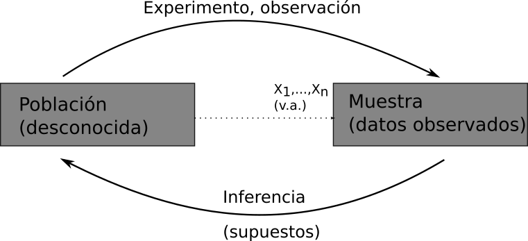

## Muestreo de la población

- Sabiendo el número de ventas en un día o visitas por hora a nuestra web podemos planificar la gestión de una tienda, carga de la web, etc.
- Supongamos que las ventas salen de una población teórica [binomial negativa](https://es.wikipedia.org/wiki/Distribuci%C3%B3n_binomial_negativa):

```r
data <- tibble(x = rnbinom(n=1e6, size=7, prob=.6))
ggplot(data, aes(x)) + geom_vline(xintercept = mean(data$x), color = "red") +
  geom_histogram(aes(y = ..density..), bins = 200) +
  stat_function(fun = dnorm, col = "green",
                args = list(mean = mean(data$x), sd = sd(data$x)))
```

- Disponemos de una muestra con información de solo \(n=25\) días

```r
set.seed(1510) # set.seed(501)  set.seed(1001)
muestra <- tibble(x = rnbinom(n=25, size=7, prob=.6))
muestra %>% summary()
```

## Incertidumbre por la distribución del muestreo

- Un *estadístico* es un valor calculado a partir de una muestra (ej., la media). ¿Cómo de fiable es?
- Simulemos la distribución de la media en muchas muestras de \(n=25\)

```r
set.seed(101)
Muestras_df <- 1:100 %>% map_dfr(~tibble(x = rnbinom(n=25, size=7, prob=.6)) %>%
                    summarize(media=mean(x), sd=sd(x)))

Muestras <- list()
set.seed(101)
for(i in 1:100){
  Muestras[[i]] <- tibble(x = rnbinom(n=25, size=7, prob=.6))  %>%
        summarize(media = mean(x), sd = sd(x))
}
Muestras_df <- Muestras %>% bind_rows()
```

## Distribuciones muestrales

- **Distribución muestral** es la distribución del estadístico en todas las muestras potenciales de **tamaño muestral \(n\)**
  - veríamos cómo varía el valor del estadístico en todas las muestras

```r
Muestras_df %>% ggplot(aes(x=media)) + geom_density()   # aquí solo 100 muestras
```

- Nos interesan su *forma*, *error estándar* (variabilidad de la distribución muestral), *intervalo de confianza*, etc.
- ¿Es posible **cuantificar la incertidumbre** con UNA MUESTRA?
  - Supuestos: si los datos son normales, la media tiene una distribución normal
- ¿Cómo cambia cuando varia el tamaño muestral?

## Distribuciones muestrales: LGN y TCL

- *Ley de números grandes*: para un tamaño de la muestra \(n\) grande, el promedio de la muestra está cerca de la media de la población
- *Teorema de Límite Central*: para un tamaño de la muestra \(n\) grande, la distribución muestral de la media es normal.
- \(\mbox{Error estándar}(\bar{X}_n) = \frac{\sigma}{\sqrt{n}},\) donde \(\sigma\) es la desviación estándar de la población.
  - Si **aumentamos el tamaño de la muestra en \(n\), el error estándar disminuirá**.
- Demostración práctica: [aquí](https://openintro.shinyapps.io/CLT_mean/)

## Procedimiento *Bootstrap*

- **Idea**: pensar en la ÚNICA muestra como si fuera la población
1. Tomar muchas *remuestras* (muestras de Bootstrap) con reemplazamiento: p.e., para (1,2,3) incluye los casos (1,1,2), (1,1,3), (2,2,1), etc.
2. En cada remuestra, se puede calcular cualquier estadístico
- La **distribución muestral bootstrap** NO es la distribución muestral, pero aproxima sus aspectos principales sin supuestos (normalidad, TCL)
- Puede aplicarse a **cualquier estadístico** (media, varianzas, regresión, etc.)

```r
boot_df <- 1:1000 %>% map_dfr(~muestra %>% slice_sample(n=25, replace = TRUE) %>%
                                summarize(media=mean(x)))
boot_df %>% ggplot(aes(x = media)) + geom_density()  # densidad bootstrap de la media
sd(boot_df$media)                                    # estimación del error estándar
c(sort(boot_df$media)[25], sort(boot_df$media)[975]) # Intervalo de confianza al 95%
```

## Procedimiento *Bootstrap* (cont.)

```r
set.seed(101)
boot_df <- list()
for (i in 1:1000) {
  data1 <- muestra %>% slice_sample(n=25, replace = TRUE)
  m <- mean(data1$x)
  s <- sd(data1$x)
  boot_df[[i]] <-  list(media = m, sd = s)
}
boot_df %>% bind_rows() %>% ggplot(aes(x = media)) + geom_density()

set.seed(101)
mis_estads <- function(n) {
  data1 <- muestra %>% slice_sample(n=n, replace = TRUE)
  sol <- list(media = mean(data1$x), sd = sd(data1$x))
  return(sol)
}
boot_df <- 1:1000 %>% map_dfr(~mis_estads(25))
boot_df %>% bind_rows() %>% ggplot(aes(x = media)) + geom_density()
```

## Modelización Condicional. Causalidad

- La población NO suele ser *homogenea*: más visitas ciertos días, horas, etc.
- Un modelo de regresión permite incluir todas las **variables explicativas** de la variación de la variable dependiente
- **“Correlación no implica causalidad”**, salvo en [ensayos científicos aleatorios](https://es.wikipedia.org/wiki/Prueba_controlada_aleatorizada) cuidadosamente controlados
  - en otros campos como marketing digital o analítica de web se denominan [pruebas A/B](https://es.wikipedia.org/wiki/Prueba_A/B) (ej. dos versiones de una misma web)
- En general (datos observacionales), nos preocupa que otros factores que puedan ser los verdaderos determinantes de la relación observada

## “Confounding factor”: Descuentos y ventas

```r
datos <- read_csv("data/discount.csv")
```

- El porcentaje medio de descuentos afecta negativamente a las ventas

```r
datos %>% ggplot(aes(x=discount, y=sales)) + geom_point() + geom_smooth(method = "lm")
```

```r
lm(data = datos, sales ~ discount) %>% summary()
```

- Pero si tenemos en cuenta la renta…

```r
datos %>% mutate(renta_baja = income < 7500) %>%
  ggplot(aes(x=discount, y=sales)) + geom_point() + geom_smooth(method = "lm") +
  facet_wrap(~renta_baja)
```

```r
lm(data = datos, sales ~ discount + income) %>% summary()
```

## Regresión Lineal

- La regresión lineal predice una respuesta cuantitativa \(\small Y\) como a partir de \(k\) regresores \(X=\) \(\small X_1,X_2,\dots,X_k\)
- Supuesto: relación lineal entre \(\small X\) e \(\small Y\) \[ \small Y=\beta_0+\beta_1 X_1+ \dots + \beta_k X_k + \varepsilon \]
- Los coeficientes o parámetros del modelo representan
  - \(\small \beta_0\) (constante): valor esperado de \(\small Y\) cuando \(\small X_1=X_2=\dots=X_k=0\)
  - \(\small \beta_j\) (pendiente de la línea): cambio medio en \(\small Y\) por un incremento de una unidad en \(\small X_j\) (para \(j=1,...,k\)), *ceteris paribus*
- Objetivo: estimar los coeficientes desconocidos a partir de una muestra

## Regresión Lineal: Estimación

- El error de estimación o **residuo** es \(\small \hat{e}_i = y_i - \hat{y}_i\), donde la predicción a partir del modelo estimado es \(\small \hat{y}_i=\hat{\beta}_0+\hat{\beta}_1 X_1+ \dots + \hat{\beta}_k X_p\)
- Los coeficientes estimados son los que minimizan la Suma Cuadrática de Residuos: la suma total de distancias entre los datos observados y predichos

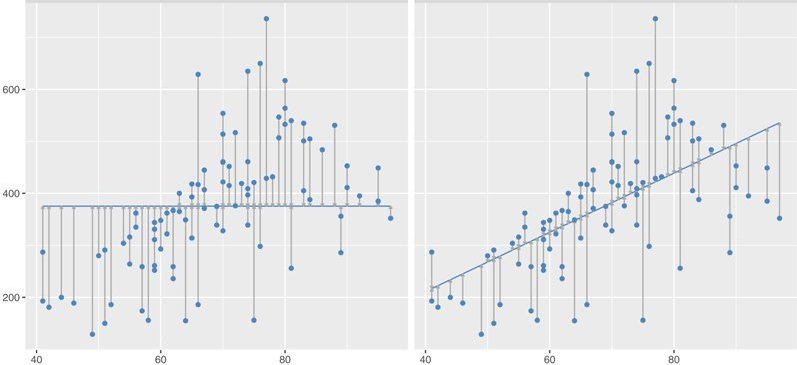

\[ \small SCR=\sum_{i=1}^{n} \hat{e}_i^2= \sum_{i=1}^{n} ( y_i - \hat{y}_i)^2 \]

- Por tanto, también minimiza \(\small MSE = \frac{SCR}{n}\)
- Esto equivale a las condiciones derivadas de suponer \(\small E(\varepsilon|X)=0\)

## Regresión Lineal: Precisión de las estimaciones

- La precisión de los coeficientes estimados se mide con el **error estándar**

\[ \small se(\widehat{\beta}_j) = \frac{\sigma^2}{(n-1)S^2_{x_j} (1 - R^2_{j})} \]

- \(\small \sigma^2=Var(\varepsilon)\), estimada con \(\small \frac{SCR}{n-k-1}\)
- \(\small S^2_{x_j}=\frac{\sum (x_{ij}-\bar{x}_j)^2}{n-1}=\)varianza muestral de \(\small X_j\)
- \(\small R^2_{j}\) es el \(\small R^2\) de la regresión de \(\small X_j\) sobre el resto de regresores
- Los errores estándar se usan para construir intervalos de confianza y estadísticos para contrastar hipótesis sobre los parámetros, p.e.,
  - significatividad individual: \(\small H_0: \beta_1=0\) con un estadístico \(\small t=\frac{\widehat{\beta}_1-0}{se(\widehat{\beta}_1)}\)
  - significatividad conjunta: \(\small H_0: \beta_1=\beta_2=\dots=\beta_k=0\) con un estadístico \(\small F\)

## Regresión Lineal: Precisión del modelo

- Medición de la precisión del modelo:
  - RMSE o variantes como el error estandar de la regresión, \(\small \sqrt{\frac{SCR}{n-k-1}}\): son medidas absolutas en las mismas unidades que \(Y\)
  - \(\small R^2=1-\frac{SCR}{SCT} = \frac{SCE}{SCT}\) es una medida relativa: proporción de la varianza explicada por el modelo
- La predicción \(\widehat{y}\) también están sujetas a incertidumbre por la estimación
  - Existen formulas para calcular su error estándar (a partir de la matriz de varianza y covarianza de los coeficientes estimados)
  - Por tanto, también se puede calcular un intervalo de confianza

```r
res <- lm(data = datos, sales ~ discount + income)
cbind(datos$sales, res$fitted.values) %>% head()
```

## Regresión Lineal: superando la linealidad

- Se pueden incluir transformaciones no lineales de las variables del modelo
- La interpretación del cambio de un regresor sobre \(\small Y\) es diferente

```r
library(ISLR)
data(Carseats)
lm(data=Carseats %>% filter(Sales != 0), log(Sales) ~ poly(Advertising,2))
```

- Otra forma de permitir no linealidades es discretizando variables continuas: permite efectos “escalón” diferentes para distintos valores

```r
lm(data=Carseats , Sales ~ cut_width(Advertising, 10)) %>% summary()
```

- Se incluyen indicadores binarios para cada clase excepto uno
  - la constante recoge el valor medio de \(\small Y\) para ese grupo de referencia
  - cada coeficiente recoge el efecto adicional de su grupo sobre \(\small Y\)

## Regresión Lineal: superando la linealidad (cont.)

- También podemos incluir interacciones entre variables: el efecto de un regresor dependerá de otro regresor

```r
lm(data=Carseats , Sales ~ Advertising*Income)
```

- Principio jerárquico: al incluir una interacción *siempre* deben incluirse los factores principales (NO sólo `Advertising:Income`)
- Cuando interactuamos un regresor continuo y uno binario, permitimos que la pendiente del primero sea diferente para cada grupo

```r
lm(data=Carseats , Sales ~ (Income + Advertising)*Urban)
```

- La interacción de dos variables binarias tiene una interpretación similar

```r
lm(data=Carseats , Sales ~ ShelveLoc*Urban)
```

## “Problemas” del Modelo de Regresión Lineal

- *No linealidad*: incluir transformaciones no lineales
- *Correlación de los errores*: afecta a los errores estándar, no la estimación
  - usar errores estándar robustos o modelizar la dinámica
- *Heterocedasticidad*: ídem, usar errores estándar robustos
  - los gráficos de los residuos frente a un regresor o valores predichos: ¿heterocedasticidad o no linealidad?
- *Outliers* en la variable de respuesta o en los regresores
- *Colinearidad*: indica que no es posible separar el efecto de cada regresor: eliminar alguno o recombinarlos
- *No normalidad*: TCL, Bootstrap,…
- El único supuesto realmente importante es \(\small E[\varepsilon|X]=0\)

## Regresión Logística

- La regresión lineal puede usarse respuestas binarias (no más de dos categorías), aunque genera predicciones fuera del rango \(\small [0,1]\)
- Solución: aplicar al índice lineal una transformación \(\small F(z)\in[0,1]\)
- La función logística: \(\small \Lambda (z)=\frac{e^z}{1+e^z}\)

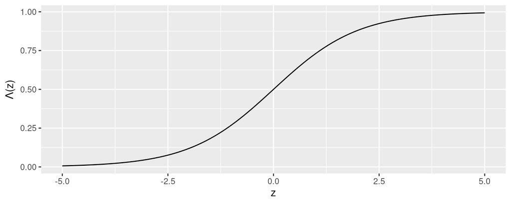

- De manera que \(\small \Pr(Y=1|X)= p(x)= \Lambda( \beta_0 + \beta_1 x_1 + \ldots + \beta_k x_k)\)

## Regresión Logística (cont.)

- Los coeficientes NO se interpretan directamente como cambios en la probabilidad ante cambios unitarios en un regresor
- PERO su signo (y significatividad) son los mismos que los del efecto marginal sobre la probabilidad
- Como NO tiene sentido minimizar la SCR, el objetivo es maximizar la probabilidad (verosimilitud) de observar los unos y ceros en los datos
- La regresión logística pertenece a la familia de modelos lineales generalizados (GLM, en inglés)
- Se pueden incluir como variables explicativas tanto variables cuantitativas como cualitativas, e incurrir en sesgo por omisión de variables

```r
glm(data = Default, default ~ student, family = "binomial" ) %>% summary()
glm(data = Default, default ~ student + balance, family = "binomial" ) %>% summary()
```

## Regresión Logística: Predicciones

- El objeto de R de `glm()` contiene valores predichos, que son probabilidades de \(\small Y=1\)

```r
logit <- glm(data = Default, default ~ balance*student, family = "binomial" )
cbind(Default$default, logit$fitted)
```

- También se puede predecir usando una muestra distinta de la usada para estimar o con valores concretos de los regresores

```r
logit <- glm(data = Default, default ~ balance, family = "binomial" )
predict(logit, newdata = tibble(balance=c(0,100)), type="response")
```

## Regresión logística con más de dos clases

- La regresión logística se puede generalizar a situaciones con múltiples clases (modelos multinomiales) con un índice lineal para cada clase \[ \small \Pr(Y=c|X)=\frac{e^{\beta_{0c}+\beta_{1c}X_1+\dots+\beta_{kc}X_k}}{\sum_{l=1}^{C}e^{\beta_{0l}+\beta_{1l}X_1+\dots+\beta_{kl}X_k}} \]
- La librería `glmnet()` permite la estimación de estos modelos

```r
library(glmnet)
iris.x <- as.matrix(iris[1:2])
iris.y <- as.matrix(iris[5])
mod.glmnet <- glmnet(x = iris.x, y = iris.y, family = "multinomial",
                     lambda = 0, type.multinomial = "grouped")
coef(mod.glmnet)

predict(mod.glmnet, newx=iris.x, type = "response")  # probabilidad de cada clase
predict(mod.glmnet, newx=iris.x, type = "class")     # clase
```